# Classification with use of original feature space

## Contents

- 1. Setting up
  - 1.1 Imports
  - 1.2 Configure parameters
  - 1.3 Custom functions
  - 1.4 Load data
- 2. Classification experiments
  - 2.1 Linear discriminant analysis
    - 2.1.1 Create grid of parameters
    - 2.1.2 Perform grid search
    - 2.1.3 Display best configurations depending on preprocessing parameters and original feature space of spectra
    - 2.1.4 Train-test accuracy plots for different combinations of (with_abs, with_mean, with_std)
  - 2.2 Logistic regression
    - 2.2.1 Create grid of parameters
    - 2.2.2 Perform grid search
    - 2.2.3 Display best configurations depending on preprocessing parameters and original feature space of spectra
    - 2.2.4 Train-test accuracy plots for different combinations of (with_abs, with_mean, with_std)
- 3. Agglomerative clustering
  - 3.1 Create grid of parameters
  - 3.2 Perform grid search
  - 3.3 Display best configurations depending on preprocessing parameters and original feature space of spectra
  - 3.4 Mosaic plots of Adjusted Rand Index depending on best performing (in conditions of fixed subset of parameters) configurations

## 1. Setting up

- 1.1 Imports
- 1.2 Configure parameters
- 1.3 Custom functions
- 1.4 Load all necessary data

Return to contents

### 1.1 Imports

Required packages are: [numpy](http://www.numpy.org/), [scipy](https://www.scipy.org/), [matplotlib](https://matplotlib.org/index.html), [seaborn](https://seaborn.pydata.org), [scikit-learn](http://scikit-learn.org/stable/index.html), [pywt](http://pywavelets.readthedocs.io/en/latest/), [pandas](https://pandas.pydata.org/), [statmodels](https://www.statsmodels.org/stable/index.html).

Up to section $\quad$ Return to contents

```python
import sys
sys.path.append('../src/')
import os

import numpy as np
import pandas as pd
import pywt

from ml_classes import baseLDA
from ml_classes import baseLR
from ml_classes import baseAC
from ml_classes import baseSC
from nonlinearity import sign_thresh

from alg_stats import get_gscv_stats
from alg_stats import GridSearchCV_unsupervised

import scipy.optimize

from files_io import ftirLoad

from sklearn.metrics import accuracy_score
from sklearn.metrics import fowlkes_mallows_score
from sklearn.metrics import adjusted_rand_score
from sklearn.metrics import adjusted_mutual_info_score

from sklearn.preprocessing import StandardScaler

from sklearn.cluster import KMeans, SpectralClustering

from sklearn.model_selection import RepeatedStratifiedKFold
from sklearn.model_selection import GridSearchCV

from statsmodels.graphics.mosaicplot import mosaic

import matplotlib as mpl
mpl.use("pgf")
mpl.rcParams.update({
    "text.usetex": True,
    "pgf.texsystem": "xelatex",
    "pgf.preamble": [
        r'\usepackage{soul}',
    ]

})
import matplotlib.pyplot as plt
import seaborn as sns
from matplotlib.patches import Patch
from matplotlib.lines import Line2D

import matplotlib.cm as cm

%matplotlib inline
#%matplotlib notebook
```

### 1.2 Configure parameters

Up to section $\quad$ Return to contents

```python
# RepeatedKFoldCV configuration
n_splits = 4
n_repeats = 20

# number of parallel jobs for GridSearchCV
nJobsGSCV = 2

# limiter for FTIR spectrum (cm^{-1})
bandLim = 2000.

# random states for CV
random_state_cv_long = 235
random_state_cv_short = 578

# legend for train-test plot
# Legend
colours = cm.rainbow(np.linspace(0, 1, 8))
markers = {
    'original': 'o',
    'd1': 's',
    'd2': '^'
}

legend_elements = [
    Patch(
        facecolor=colours[7],
        label=r'$\overline{\mathrm{abs}}$/$\overline{\mathrm{mean}}$/$\overline{\mathrm{std}}$'
    ),
    Patch(
        facecolor=colours[6],
        label=r'$\overline{\mathrm{abs}}$/$\overline{\mathrm{mean}}$/std'
    ),
    Patch(
        facecolor=colours[5],
        label=r'$\overline{\mathrm{abs}}$/mean/$\overline{\mathrm{std}}$'
    ),
    Patch(
        facecolor=colours[4],
        label=r'$\overline{\mathrm{abs}}$/mean/std'
    ),
    Patch(
        facecolor=colours[3],
        label=r'abs/$\overline{\mathrm{mean}}$/$\overline{\mathrm{std}}$'
    ),
    Patch(
        facecolor=colours[2],
        label=r'abs/$\overline{\mathrm{mean}}$/std'
    ),
    Patch(
        facecolor=colours[1],
        label=r'abs/mean/$\overline{\mathrm{std}}$'
    ),
    Patch(
        facecolor=colours[0],
        label=r'abs/mean/std'
    ),


    Line2D(
        [0], [0], marker=markers['original'], color='w', label=r'$f$',
        markerfacecolor='black', markersize=10
    ),
    Line2D(
        [0], [0], marker=markers['d1'], color='w', label=r'$f^{\prime}$',
        markerfacecolor='black', markersize=10
    ),
    Line2D(
        [0], [0], marker=markers['d2'], color='w', label=r'$f^{\prime\prime}$',
        markerfacecolor='black', markersize=10
    ),
]
```

### 1.3 Custom functions

Up to section $\quad$ Return to contents

```python
### Get statistics from grid search
def df2vec3(df, which='mean'):
    keys = df.columns.values

    param = df['params'].map(eval)
    keys = filter(lambda x: x.startswith('split'), keys)
    test_score_keys = filter(lambda x: x.endswith('test_score'), keys)
    test_score_keys = filter(lambda x: not (('mean' in x) or ('std' in x)), test_score_keys)
    test_score = df[test_score_keys].values #[df[key].values for key in test_score_keys]
    #test_score = np.vstack(test_score)
    train_score_keys = filter(lambda x: x.endswith('train_score'), keys)
    train_score_keys = filter(lambda x: not (('mean' in x) or ('std' in x)), train_score_keys)
    train_score = df[train_score_keys].values #[df[key].values for key in train_score_keys]
    #train_score = np.vstack(train_score)
    if which == 'mean':
        rv_train = np.mean(train_score, axis=1)
        rv_test = np.mean(test_score, axis=1)
    elif which == 'median':
        rv_train = np.median(train_score, axis=1)
        rv_test = np.median(test_score, axis=1)
    else:
        raise ValueError
    return rv_train, rv_test, param


def df2vec3_fromDirectory(dirname, filename_base, which='mean'):
    filenames = os.listdir(dirname)
    filenames = filter(lambda x: x.startswith(filename_base), filenames)
    filenames = sorted(filenames, key=stringSplitByNumbers)
    df_composed = []
    for i_fnm in xrange(len(filenames)):
        filename = filenames[i_fnm]
        df = pd.read_csv(dirname+filename)
        keys = df.columns.values
        #param = df['params']
        df.set_index('params', drop=True, append=False, inplace=True, verify_integrity=False)
        keys = filter(lambda x: (x.startswith('split')) or (x.endswith('train_score')), keys)
        df_composed.append( df[keys] )
    df_composed = pd.concat(df_composed, axis=1)
    df_composed['params'] = df.index
    return df2vec3(df_composed, which)


def get_indices_lda_original(gparams, with_abs, with_mean, with_std):
    indices = map(
        lambda x: (
            (x['with_abs']==with_abs) and
            (x['with_mean'] == with_mean) and
            (x['with_std'] == with_std)
        ),
        gparams
    )
    return indices



def get_indices_lr_original(gparams, penalty, with_abs, with_mean, with_std):
    indices = map(
        lambda x: (
            (x['penalty'] == penalty) and
            (x['with_abs'] == with_abs) and
            (x['with_mean'] == with_mean) and
            (x['with_std'] == with_std)),
        gparams
    )
    return indices

def custom_mosaic_plain(mosaic_data, mosaic_data_3var_dict, cmapInstance):
    properties = lambda key: {'color': cmapInstance(mosaic_data[tuple(map(int, key))])}
    fig, rect = mosaic(
        mosaic_data, gap=0.05, labelizer=lambda x: '',
        properties=properties
    )
    fig.set_size_inches(4, 3)
    ax = fig.axes
    ax0 = ax[0]
    ax0.set_xlabel('Standard scaling axis')
    yticks = ax0.get_yticklabels()
    yticks = map(lambda x: mosaic_data_3var_dict[x.get_text()], yticks)
    ax0.set_yticklabels(yticks)
    return fig, rect
```

### 1.4 Load all necessary data

Up to section $\quad$ Return to contents

```python
data_dirname = '../data/'

## data with smaller resolution
fnms1 = [
    '08-07-2017-baselinecorrected.csv',
    '22-09-2017-baselinecorrected.csv'
]

## data with higher resolution
fnms2 = [
    '16-04-2018-baselinecorrected.csv',
    '18-04-2018-baselinecorrected.csv'
]

X1, labels1, freq = ftirLoad(fnms1, dirname=data_dirname)
X2, labels2, freq2 = ftirLoad(fnms2, dirname=data_dirname)

## v.2018 sampled more precisely; discretization points are exactly the same
X = np.hstack([X1[:-1, :], X2[::2, :]])
labels = labels1.tolist() + labels2.tolist()
labels = np.array(labels, dtype='i')
ind = np.where(freq <= bandLim)[0]
X, freq = X[ind], freq[ind]
Nsamples = X.shape[1]

# plain data for DWT
plainT = 0.01*X
# first order derivative data for DWT
dT = (plainT[2:] - plainT[:-2]) / (2.*np.reshape(freq[2:] - freq[:-2], [-1, 1]))
dFreq = freq[1:-1].copy()

# second order derivative data for DWT
d2T = (plainT[2:] - 2*plainT[1:-1] + plainT[:-2]) / np.reshape(freq[2:] - freq[:-2], [-1, 1])**2.
d2Freq = freq[1:-1].copy()

# generate CV indices
separator_long = RepeatedStratifiedKFold(
    n_splits=n_splits, n_repeats=n_repeats, random_state=random_state_cv_long
)
separator_short = RepeatedStratifiedKFold(
    n_splits=n_splits, n_repeats=1, random_state=random_state_cv_short
)

dummyX = np.empty(Nsamples)
train_indices_long, test_indices_long = [], []
for train_index, test_index in separator_long.split(dummyX, labels):
    train_indices_long.append(train_index)
    test_indices_long.append(test_index)

train_indices_short, test_indices_short = [], []
for train_index, test_index in separator_short.split(dummyX, labels):
    train_indices_short.append(train_index)
    test_indices_short.append(test_index)
custom_cv_short = zip(train_indices_short[:n_splits], test_indices_short[:n_splits])
```

```
63 (1869, 63)
17 (3736, 17)
```

## 2. Experiments with unprocessed (plain) data

By the words ''unprocessed'' we mean that DWT or WTT were not performed to extract features from data.

- 2.1 Linear discriminant analysis
  - 2.1.1 Create grid of parameters
  - 2.1.2 Perform grid search
  - 2.1.3 Display best configurations depending on preprocessing parameters and original feature space of spectra
  - 2.1.4 Train-test accuracy plots for different combinations of (with_abs, with_mean, with_std)
- 2.2 Logistic regression
  - 2.2.1 Create grid of parameters
  - 2.2.2 Perform grid search
  - 2.2.3 Display best configurations depending on preprocessing parameters and original feature space of spectra
  - 2.2.4 Train-test accuracy plots for different combinations of (with_abs, with_mean, with_std)

Return to contents

### 2.1 Linear discriminant analysis

- 2.1.1 Create grid of parameters
- 2.1.2 Perform grid search
- 2.1.3 Display best configurations depending on preprocessing parameters and original feature space of spectra
- 2.1.4 Train-test accuracy plots for different combinations of (with_abs, with_mean, with_std)

Up to section $\quad$ Return to contents

#### 2.1.1 Create grid of parameters

Up to subsection $\quad$ Up to section $\quad$ Return to contents

```python
param_grid = {}
param_grid['with_mean'] = [True, False]
param_grid['with_std'] = [True, False]
param_grid['with_abs'] = [True, False]

filename_base = 'gscv_original_lda_'
results_dirname = '../results/unprocessed/lda/'
if not os.path.isdir(results_dirname):
    os.makedirs(results_dirname)
```

#### 2.1.2 Perform grid search

Up to subsection $\quad$ Up to section $\quad$ Return to contents

```python
gscv_original_lda_plain = GridSearchCV(
    estimator=baseLDA(), param_grid=param_grid, cv=custom_cv_short, verbose=True,
    return_train_score=True, scoring='accuracy', n_jobs=nJobsGSCV
)

gscv_original_lda_d1 = GridSearchCV(
    estimator=baseLDA(), param_grid=param_grid, cv=custom_cv_short, verbose=True,
    return_train_score=True, scoring='accuracy', n_jobs=nJobsGSCV
)

gscv_original_lda_d2 = GridSearchCV(
    estimator=baseLDA(), param_grid=param_grid, cv=custom_cv_short, verbose=True,
    return_train_score=True, scoring='accuracy', n_jobs=nJobsGSCV
)

gscv_original_lda_plain.fit(plainT.T, labels);
df_original_lda_plain = pd.DataFrame(gscv_original_lda_plain.cv_results_)
df_original_lda_plain.to_csv(results_dirname+filename_base+'plain.csv', index=False)

gscv_original_lda_d1.fit(dT.T, labels);
df_original_lda_d1 = pd.DataFrame(gscv_original_lda_d1.cv_results_)
df_original_lda_d1.to_csv(results_dirname+filename_base+'d1.csv', index=False)

gscv_original_lda_d2.fit(d2T.T, labels);
df_original_lda_d2 = pd.DataFrame(gscv_original_lda_d2.cv_results_)
df_original_lda_d2.to_csv(results_dirname+filename_base+'d2.csv', index=False)
```

#### 2.1.3 Display best configurations depending on preprocessing parameters and original feature space of spectra

Up to subsection $\quad$ Up to section $\quad$ Return to contents

```python
results_dirname = '../results/unprocessed/lda/'
filename_base = 'gscv_original_lda_'

if not os.path.isdir(results_dirname):
    os.makedirs(results_dirname)

df_original_lda_plain = pd.read_csv(results_dirname+filename_base+'plain.csv')
df_original_lda_d1 = pd.read_csv(results_dirname+filename_base+'d1.csv')
df_original_lda_d2 = pd.read_csv(results_dirname+filename_base+'d2.csv')

parBool = [
    len(param_grid['with_abs']),
    len(param_grid['with_mean']),
    len(param_grid['with_std'])
]
loopParamNames = [
    'with_abs',
    'with_mean',
    'with_std'
]
ntab = np.prod(parBool)

for k in xrange(ntab):
    index = np.unravel_index(k, parBool, order='C')
    current_param_values = [param_grid[loopParamNames[i]][index[i]] for i in xrange(len(loopParamNames))]
    with_abs, with_mean, with_std = current_param_values

    train_score, test_score, gparams = df2vec3(df_original_lda_plain)
    indices = get_indices_lda_original(gparams, with_abs, with_mean, with_std)
    train_lda_plain, test_lda_plain = train_score[indices], test_score[indices]

    train_score, test_score, gparams = df2vec3(df_original_lda_d1)
    indices = get_indices_lda_original(gparams, with_abs, with_mean, with_std)
    train_lda_d1, test_lda_d1 = train_score[indices], test_score[indices]

    train_score, test_score, gparams = df2vec3(df_original_lda_d2)
    indices = get_indices_lda_original(gparams, with_abs, with_mean, with_std)
    train_lda_d2, test_lda_d2 = train_score[indices], test_score[indices]

    df_out = {}
    df_out['train'] = {
        'original:': train_lda_plain,
        '1st derivative:': train_lda_d1,
        '2nd derivative:': train_lda_d2
    }
    df_out['test'] = {
        'original:': test_lda_plain,
        '1st derivative:': test_lda_d1,
        '2nd derivative:': test_lda_d2
    }
    config_string = 'with_abs=%d, with_mean=%d, with_std=%d' % (with_abs, with_mean, with_std)
    df_out = pd.DataFrame(df_out)
    print config_string
    print df_out
```

```
with_abs=1, with_mean=1, with_std=1
                                  test                 train
1st derivative:   [0.6851954418130888]  [0.8745674579982002]
2nd derivative:   [0.5700693913929208]  [0.8283991075487277]
original:        [0.31254456327985736]  [0.9539753277114469]
with_abs=1, with_mean=1, with_std=0
                                  test                 train
1st derivative:   [0.6851954418130888]  [0.8745674579982002]
2nd derivative:   [0.5700693913929208]  [0.8283991075487277]
original:        [0.31254456327985736]  [0.9539753277114469]
with_abs=1, with_mean=0, with_std=1
                                 test                 train
1st derivative:  [0.8047205245734657]  [0.9370943614149343]
2nd derivative:  [0.7320473644003055]  [0.8869237798372807]
original:        [0.8468996689584924]                 [1.0]
with_abs=1, with_mean=0, with_std=0
                                 test                 train
1st derivative:  [0.8047205245734657]  [0.9370943614149343]
2nd derivative:  [0.7320473644003055]  [0.8869237798372807]
original:        [0.8468996689584924]                 [1.0]
with_abs=0, with_mean=1, with_std=1
                                 test                 train
1st derivative:  [0.8842787114845938]  [0.9831190337034873]
2nd derivative:  [0.7867392411510059]  [0.9456419943781136]
original:        [0.8497007894066718]                 [1.0]
with_abs=0, with_mean=1, with_std=0
                                 test                 train
1st derivative:  [0.8842787114845938]  [0.9831190337034873]
2nd derivative:  [0.7867392411510059]  [0.9456419943781136]
original:        [0.8497007894066718]                 [1.0]
with_abs=0, with_mean=0, with_std=1
                                 test                 train
1st derivative:  [0.8842787114845938]  [0.9831190337034873]
2nd derivative:  [0.7867392411510059]  [0.9456419943781136]
original:        [0.8497007894066718]                 [1.0]
with_abs=0, with_mean=0, with_std=0
                                 test                 train
1st derivative:  [0.8842787114845938]  [0.9831190337034873]
2nd derivative:  [0.7867392411510059]  [0.9456419943781136]
original:        [0.8497007894066718]                 [1.0]
```

#### 2.1.4 Train-test accuracy plots for different combinations of (with_abs, with_mean, with_std)

Up to subsection $\quad$ Up to section $\quad$ Return to contents

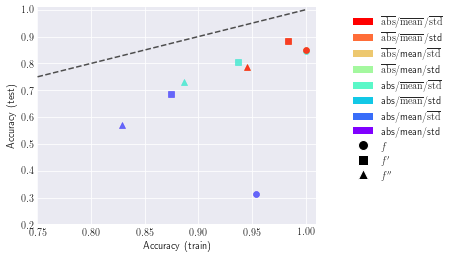

```python
results_dirname = '../results/unprocessed/lda/'
filename_base = 'gscv_original_lda_'

df_original_lda_plain = pd.read_csv(results_dirname+filename_base+'plain.csv')
df_original_lda_d1 = pd.read_csv(results_dirname+filename_base+'d1.csv')
df_original_lda_d2 = pd.read_csv(results_dirname+filename_base+'d2.csv')

parBool = [
    len(param_grid['with_abs']),
    len(param_grid['with_mean']),
    len(param_grid['with_std'])
]
loopParamNames = [
    'with_abs',
    'with_mean',
    'with_std'
]
ntab = np.prod(parBool)

sns.set_style('darkgrid')
f, ax = plt.subplots(1, 1, figsize=(5, 4))
colours = cm.rainbow(np.linspace(0, 1, 8))
markers = {
    'original': 'o',
    'd1': 's',
    'd2': '^'
}

for k in xrange(ntab):
    index = np.unravel_index(k, parBool, order='C')
    current_param_values = [param_grid[loopParamNames[i]][index[i]] for i in xrange(len(loopParamNames))]
    with_abs, with_mean, with_std = current_param_values
    current_param_values = tuple(current_param_values)

    train_score, test_score, gparams = df2vec3(df_original_lda_plain)
    indices = get_indices_lda_original(gparams, with_abs, with_mean, with_std)
    train_lda_plain, test_lda_plain = train_score[indices], test_score[indices]
    ax.scatter(
        train_lda_plain, test_lda_plain, marker=markers['original'],
        color=colours[k], alpha=0.6,
        linewidth=0.5
    )
    train_score, test_score, gparams = df2vec3(df_original_lda_d1)
    indices = get_indices_lda_original(gparams, with_abs, with_mean, with_std)
    train_lda_d1, test_lda_d1 = train_score[indices], test_score[indices]
    ax.scatter(
        train_lda_d1, test_lda_d1, marker=markers['d1'],
        color=colours[k], alpha=0.6,
        linewidth=0.5
    )

    train_score, test_score, gparams = df2vec3(df_original_lda_d2)
    indices = get_indices_lda_original(gparams, with_abs, with_mean, with_std)
    train_lda_d2, test_lda_d2 = train_score[indices], test_score[indices]
    ax.scatter(
        train_lda_d2, test_lda_d2, marker=markers['d2'],
        color=colours[k], alpha=0.6,
        linewidth=0.5
    )
ax.set_xlim([0.75, 1.01])
ax.set_ylim([0.2, 1.01])
ax.set_xlabel('Accuracy (train)')
ax.set_ylabel('Accuracy (test)')
ax.plot([0., 1.], [0., 1.], ls="--", c=".3")

ax.legend(handles=legend_elements, ncol=1, bbox_to_anchor=(1.1, 1.))

plt.show()
```

### 2.2 Logistic regression

- 2.2.1 Create grid of parameters
- 2.2.2 Perform grid search
- 2.2.3 Display best configurations depending on preprocessing parameters and original feature space of spectra
- 2.2.4 Train-test accuracy plots for different combinations of (with_abs, with_mean, with_std)

Up to section $\quad$ Return to contents

#### 2.2.1 Create grid of parameters

Up to subsection $\quad$ Up to section $\quad$ Return to contents

```python
param_grid = {}
param_grid['C'] = np.power(10., np.arange(-5, 6))
param_grid['penalty'] = ['l1', 'l2']
param_grid['with_mean'] = [True, False]
param_grid['with_std'] = [True, False]
param_grid['with_abs'] = [True, False]

results_dirname = '../results/unprocessed/lr/'
if not os.path.isdir(results_dirname):
    os.makedirs(results_dirname)
filename_base = 'gscv_original_lr_'
```

#### 2.2.2 Perform grid search

Up to subsection $\quad$ Up to section $\quad$ Return to contents

```python
gscv_original_lr_plain = GridSearchCV(
    estimator=baseLR(solver='saga', multi_class='ovr'), param_grid=param_grid,
    cv=custom_cv_short, verbose=True, return_train_score=True, scoring='accuracy',
    n_jobs=nJobsGSCV
)

gscv_original_lr_d1 = GridSearchCV(
    estimator=baseLR(solver='saga', multi_class='ovr'), param_grid=param_grid,
    cv=custom_cv_short, verbose=True, return_train_score=True, scoring='accuracy',
    n_jobs=nJobsGSCV
)

gscv_original_lr_d2 = GridSearchCV(
    estimator=baseLR(solver='saga', multi_class='ovr'), param_grid=param_grid,
    cv=custom_cv_short, verbose=True, return_train_score=True, scoring='accuracy',
    n_jobs=nJobsGSCV
)

gscv_original_lr_plain.fit(plainT.T, labels);
df_original_lr_plain = pd.DataFrame(gscv_original_lr_plain.cv_results_)
df_original_lr_plain.to_csv(results_dirname+filename_base+'plain.csv', index=False)

gscv_original_lr_d1.fit(dT.T, labels);
df_original_lr_d1 = pd.DataFrame(gscv_original_lr_d1.cv_results_)
df_original_lr_d1.to_csv(results_dirname+filename_base+'d1.csv', index=False)

gscv_original_lr_d2.fit(d2T.T, labels);
df_original_lr_d2 = pd.DataFrame(gscv_original_lr_d2.cv_results_)
df_original_lr_d2.to_csv(results_dirname+filename_base+'d2.csv', index=False)
```

#### 2.2.3 Display best configurations depending on preprocessing parameters and original feature space of spectra

Up to subsection $\quad$ Up to section $\quad$ Return to contents

```python
filename_base = 'gscv_original_lr_'
results_dirname = '../results/unprocessed/lr/'

if not os.path.isdir(results_dirname):
    os.makedirs(results_dirname)

df_original_lr_plain = pd.read_csv(results_dirname+filename_base+'plain.csv')
df_original_lr_d1 = pd.read_csv(results_dirname+filename_base+'d1.csv')
df_original_lr_d2 = pd.read_csv(results_dirname+filename_base+'d2.csv')

parBool = [
    len(param_grid['with_abs']),
    len(param_grid['with_mean']),
    len(param_grid['with_std'])
]
loopParamNames = [
    'with_abs',
    'with_mean',
    'with_std'
]
ntab = np.prod(parBool)

for k in xrange(ntab):
    index = np.unravel_index(k, parBool, order='C')
    current_param_values = [param_grid[loopParamNames[i]][index[i]] for i in xrange(len(loopParamNames))]
    with_abs, with_mean, with_std = current_param_values

    train_score, test_score, gparams = df2vec3(df_original_lr_plain)
    #print gparams[indices]
    penalty = 'l1'
    indices = get_indices_lr_original(gparams, penalty, with_abs, with_mean, with_std)
    train_lr_plain_l1, test_lr_plain_l1 = train_score[indices], test_score[indices]
    penalty = 'l2'
    indices = get_indices_lr_original(gparams, penalty, with_abs, with_mean, with_std)
    train_lr_plain_l2, test_lr_plain_l2 = train_score[indices], test_score[indices]

    train_score, test_score, gparams = df2vec3(df_original_lr_d1)
    #print gparams[indices]
    penalty = 'l1'
    indices = get_indices_lr_original(gparams, penalty, with_abs, with_mean, with_std)
    train_lr_d1_l1, test_lr_d1_l1 = train_score[indices], test_score[indices]
    penalty = 'l2'
    indices = get_indices_lr_original(gparams, penalty, with_abs, with_mean, with_std)
    train_lr_d1_l2, test_lr_d1_l2 = train_score[indices], test_score[indices]

    train_score, test_score, gparams = df2vec3(df_original_lr_d2)
    #print gparams[indices]
    penalty = 'l1'
    indices = get_indices_lr_original(gparams, penalty, with_abs, with_mean, with_std)
    train_lr_d2_l1, test_lr_d2_l1 = train_score[indices], test_score[indices]
    penalty = 'l2'
    indices = get_indices_lr_original(gparams, penalty, with_abs, with_mean, with_std)
    train_lr_d2_l2, test_lr_d2_l2 = train_score[indices], test_score[indices]

    train_lr_plain_score = np.vstack([train_lr_plain_l1, train_lr_plain_l2])
    train_lr_d1_score = np.vstack([train_lr_d1_l1, train_lr_d1_l2])
    train_lr_d2_score = np.vstack([train_lr_d2_l1, train_lr_d2_l2])
    test_lr_plain_score = np.vstack([test_lr_plain_l1, test_lr_plain_l2])
    test_lr_d1_score = np.vstack([test_lr_d1_l1, test_lr_d1_l2])
    test_lr_d2_score = np.vstack([test_lr_d2_l1, test_lr_d2_l2])

    ind1 = np.where(test_lr_plain_score == test_lr_plain_score.max())
    ind1 = tuple(map(lambda x: x[0], ind1))
    ind2 = np.where(test_lr_d1_score == test_lr_d1_score.max())
    ind2 = tuple(map(lambda x: x[0], ind2))
    ind3 = np.where(test_lr_d2_score == test_lr_d2_score.max())
    ind3 = tuple(map(lambda x: x[0], ind3))


    df_out = {}
    df_out['train'] = {
        'original (%s, C=%.1e)' % (
            param_grid['penalty'][ind1[0]],
            param_grid['C'][ind1[1]]
        ): train_lr_plain_score[ind1],
        '1st deriv. (%s, C=%.1e)' % (
            param_grid['penalty'][ind2[0]],
            param_grid['C'][ind2[1]]
        ): train_lr_d1_score[ind2],
        '2nd deriv. (%s, C=%.1e)' % (
            param_grid['penalty'][ind3[0]],
            param_grid['C'][ind3[1]]
        ): train_lr_d2_score[ind3],
    }
    df_out['test'] = {
        'original (%s, C=%.1e)' % (
            param_grid['penalty'][ind1[0]],
            param_grid['C'][ind1[1]]
        ): test_lr_plain_score[ind1],
        '1st deriv. (%s, C=%.1e)' % (
            param_grid['penalty'][ind2[0]],
            param_grid['C'][ind2[1]]
        ): test_lr_d1_score[ind2],
        '2nd deriv. (%s, C=%.1e)' % (
            param_grid['penalty'][ind3[0]],
            param_grid['C'][ind3[1]]
        ): test_lr_d2_score[ind3],
    }
    config_string = 'with_abs=%d, with_mean=%d, with_std=%d' % (with_abs, with_mean, with_std)
    df_out = pd.DataFrame(df_out)
    print config_string
    print df_out
```

```
with_abs=1, with_mean=1, with_std=1
                                test    train
1st deriv. (l1, C=1.0e+03)  0.799768  1.00000
2nd deriv. (l1, C=1.0e+04)  0.662997  0.97053
original (l1, C=1.0e-01)    0.261475  0.33374
with_abs=1, with_mean=1, with_std=0
                                test     train
1st deriv. (l1, C=1.0e-05)  0.174691  0.166627
2nd deriv. (l1, C=1.0e+05)  0.174691  0.174960
original (l1, C=1.0e+04)    0.238681  0.313000
with_abs=1, with_mean=0, with_std=1
                                test     train
1st deriv. (l1, C=1.0e+00)  0.897320  0.987286
2nd deriv. (l1, C=1.0e+03)  0.787214  0.987286
original (l1, C=1.0e+01)    0.648832  0.693972
with_abs=1, with_mean=0, with_std=0
                                test     train
1st deriv. (l1, C=1.0e+04)  0.174691  0.174960
2nd deriv. (l1, C=1.0e+04)  0.174691  0.158691
original (l2, C=1.0e+04)    0.345512  0.312136
with_abs=0, with_mean=1, with_std=1
                                test     train
1st deriv. (l2, C=1.0e+01)  0.962026  0.987286
2nd deriv. (l1, C=1.0e+01)  0.925121  0.987286
original (l1, C=1.0e+02)    0.716285  0.878175
with_abs=0, with_mean=1, with_std=0
                                test     train
1st deriv. (l1, C=1.0e-01)  0.174691  0.154524
2nd deriv. (l1, C=1.0e+05)  0.174691  0.174960
original (l2, C=1.0e+04)    0.345512  0.316373
with_abs=0, with_mean=0, with_std=1
                                test     train
1st deriv. (l1, C=1.0e+00)  0.948389  0.987286
2nd deriv. (l1, C=1.0e+01)  0.907614  0.991452
original (l1, C=1.0e+02)    0.634126  0.693972
with_abs=0, with_mean=0, with_std=0
                                test     train
1st deriv. (l1, C=1.0e+04)  0.174691  0.174960
2nd deriv. (l1, C=1.0e+05)  0.174691  0.174960
original (l2, C=1.0e+04)    0.345512  0.312136
```

Up to subsection $\quad$ Up to section $\quad$ Return to contents

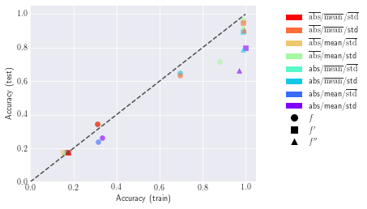

```python
results_dirname = '../results/unprocessed/lr/'
filename_base = 'gscv_original_lr_'

#'with_abs', 'with_mean', 'with_std'



df_original_lr_plain = pd.read_csv(results_dirname+filename_base+'plain.csv')
df_original_lr_d1 = pd.read_csv(results_dirname+filename_base+'d1.csv')
df_original_lr_d2 = pd.read_csv(results_dirname+filename_base+'d2.csv')

parBool = [
    len(param_grid['with_abs']),
    len(param_grid['with_mean']),
    len(param_grid['with_std'])
]
loopParamNames = [
    'with_abs',
    'with_mean',
    'with_std'
]
ntab = np.prod(parBool)

f, ax = plt.subplots(1, 1, figsize=(5, 4))
sns.set_style('darkgrid')


for k in xrange(ntab):
    index = np.unravel_index(k, parBool, order='C')
    current_param_values = [param_grid[loopParamNames[i]][index[i]] for i in xrange(len(loopParamNames))]
    with_abs, with_mean, with_std = current_param_values

    train_score, test_score, gparams = df2vec3(df_original_lr_plain)
    #print gparams[indices]
    penalty = 'l1'
    indices = get_indices_lr_original(gparams, penalty, with_abs, with_mean, with_std)
    train_lr_plain_l1, test_lr_plain_l1 = train_score[indices], test_score[indices]
    penalty = 'l2'
    indices = get_indices_lr_original(gparams, penalty, with_abs, with_mean, with_std)
    train_lr_plain_l2, test_lr_plain_l2 = train_score[indices], test_score[indices]

    train_score, test_score, gparams = df2vec3(df_original_lr_d1)
    #print gparams[indices]
    penalty = 'l1'
    indices = get_indices_lr_original(gparams, penalty, with_abs, with_mean, with_std)
    train_lr_d1_l1, test_lr_d1_l1 = train_score[indices], test_score[indices]
    penalty = 'l2'
    indices = get_indices_lr_original(gparams, penalty, with_abs, with_mean, with_std)
    train_lr_d1_l2, test_lr_d1_l2 = train_score[indices], test_score[indices]

    train_score, test_score, gparams = df2vec3(df_original_lr_d2)
    #print gparams[indices]
    penalty = 'l1'
    indices = get_indices_lr_original(gparams, penalty, with_abs, with_mean, with_std)
    train_lr_d2_l1, test_lr_d2_l1 = train_score[indices], test_score[indices]
    penalty = 'l2'
    indices = get_indices_lr_original(gparams, penalty, with_abs, with_mean, with_std)
    train_lr_d2_l2, test_lr_d2_l2 = train_score[indices], test_score[indices]

    train_lr_plain_score = np.vstack([train_lr_plain_l1, train_lr_plain_l2])
    train_lr_d1_score = np.vstack([train_lr_d1_l1, train_lr_d1_l2])
    train_lr_d2_score = np.vstack([train_lr_d2_l1, train_lr_d2_l2])
    test_lr_plain_score = np.vstack([test_lr_plain_l1, test_lr_plain_l2])
    test_lr_d1_score = np.vstack([test_lr_d1_l1, test_lr_d1_l2])
    test_lr_d2_score = np.vstack([test_lr_d2_l1, test_lr_d2_l2])

    ind1 = np.where(test_lr_plain_score == test_lr_plain_score.max())
    ind1 = tuple(map(lambda x: x[0], ind1))
    ind2 = np.where(test_lr_d1_score == test_lr_d1_score.max())
    ind2 = tuple(map(lambda x: x[0], ind2))
    ind3 = np.where(test_lr_d2_score == test_lr_d2_score.max())
    ind3 = tuple(map(lambda x: x[0], ind3))




    ax.scatter(
        train_lr_plain_score[ind1], test_lr_plain_score[ind1], marker=markers['original'],
        color=colours[k], alpha=0.6,
        linewidth=0.5
    )

    ax.scatter(
        train_lr_d1_score[ind2], test_lr_d1_score[ind2], marker=markers['d1'],
        color=colours[k], alpha=0.6,
        linewidth=0.5
    )

    ax.scatter(
        train_lr_d2_score[ind3], test_lr_d2_score[ind3], marker=markers['d2'],
        color=colours[k], alpha=0.6,
        linewidth=0.5
    )
ax.set_xlim([0., 1.05])
ax.set_ylim([0., 1.05])
ax.set_xlabel('Accuracy (train)')
ax.set_ylabel('Accuracy (test)')
ax.plot([0., 1.], [0., 1.], ls="--", c=".3")

ax.legend(handles=legend_elements, ncol=1, bbox_to_anchor=(1.1, 1.))

plt.show()
```

## 3. Agglomerative Clustering

- 3.1 Create grid of parameters
- 3.2 Perform grid search
- 3.3 Display best configurations depending on preprocessing parameters and original feature space of spectra
- 3.4 Mosaic plots of Adjusted Rand Index depending on best performing (in conditions of fixed subset of parameters) configurations

Return to contents

#### 3.1 Create grid of parameters

Up to section $\quad$ Return to contents

```python
param_grid = {}
param_grid['with_mean'] = [True, False]
param_grid['with_std'] = [True, False]
param_grid['with_abs'] = [True, False]
param_grid['stsc_axis'] = [0, 1]
param_grid['affinity'] = ['l1', 'l2', 'cosine', 'rbf']
param_grid['linkage'] = ['complete', 'average']
```

#### 3.2 Perform grid search

Up to section $\quad$ Return to contents

```python
scoring = [
    adjusted_mutual_info_score,
    adjusted_rand_score,
    fowlkes_mallows_score
]

results_dirname = '../results/unprocessed/ac/'
if not os.path.isdir(results_dirname):
    os.makedirs(results_dirname)
filename_base = 'gscv_original_ac_'

n_clusters = len(np.unique(labels))

res_original_plain, axes_original_plain = GridSearchCV_unsupervised(
    estimator=baseAC(n_clusters=n_clusters), X=plainT.T, y=labels, param_grid=param_grid,
    cv=train_indices_short, scoring=scoring, verbose=True, nEval=1
)
np.savez_compressed(
    results_dirname+filename_base+'plain.npz',
    res_original_plain=res_original_plain,
    axes_original_plain=axes_original_plain
)
print 'Results are ready for plain data'
res_original_d1, axes_original_d1 = GridSearchCV_unsupervised(
    estimator=baseAC(n_clusters=n_clusters), X=dT.T, y=labels, param_grid=param_grid,
    cv=train_indices_short, scoring=scoring, verbose=True, nEval=1
)
np.savez_compressed(
    results_dirname+filename_base+'d1.npz',
    res_original_d1=res_original_d1,
    axes_original_d1=axes_original_d1
)

print 'Results are ready for 1st derivative data'
res_original_d2, axes_original_d2 = GridSearchCV_unsupervised(
    estimator=baseAC(n_clusters=n_clusters), X=d2T.T, y=labels, param_grid=param_grid,
    cv=train_indices_short, scoring=scoring, verbose=True, nEval=1
)
np.savez_compressed(
    results_dirname+filename_base+'d2.npz',
    res_original_d2=res_original_d2,
    axes_original_d2=axes_original_d2
)
print 'Results are ready for 2nd derivative data'
```

#### 3.3 Display best configurations depending on preprocessing parameters and original feature space of spectra

Up to section $\quad$ Return to contents

```python
results_dirname = '../results/unprocessed/ac/'
filename_base = 'gscv_original_ac_'

if not os.path.isdir(results_dirname):
    os.makedirs(results_dirname)

df = np.load(results_dirname+filename_base+'plain.npz')
df_original_ac_plain = np.mean(np.mean(df['res_original_plain'], axis=-2), axis=-2)
print 'Axes of loaded results array (plain): ' + ', '.join([x for x in df['axes_original_plain']])
df = np.load(results_dirname+filename_base+'d1.npz')
df_original_ac_d1 = np.mean(np.mean(df['res_original_d1'], axis=-2), axis=-2)
print 'Axes of loaded results array (d1): ' + ', '.join([x for x in df['axes_original_d1']])
df = np.load(results_dirname+filename_base+'d2.npz')
df_original_ac_d2 = np.mean(np.mean(df['res_original_d2'], axis=-2), axis=-2)
print 'Axes of loaded results array (d2): ' + ', '.join([x for x in df['axes_original_d2']])

parBool = [
    len(param_grid['stsc_axis']),
    len(param_grid['with_abs']),
    len(param_grid['with_mean']),
    len(param_grid['with_std'])
]
loopParamNames = [
    'stsc_axis',
    'with_abs',
    'with_mean',
    'with_std'
]
ntab = np.prod(parBool)
scoringNames = [
    'Adjusted MI',
    'Adjusted Rand',
    'Fowlkes-Mallows'
]
ari_sn_i = scoringNames.index('Adjusted Rand')

mosaic_data_ari_plain = {}
mosaic_data_ari_d1 = {}
mosaic_data_ari_d2 = {}
mosaic_data_3var_dict = {
    '7': r'$\xcancel{\mathrm{abs}}$/$\xcancel{\mathrm{mean}}$/$\xcancel{\mathrm{std}}$',
    '6': r'$\xcancel{\mathrm{abs}}$/$\xcancel{\mathrm{mean}}$/std',
    '5': r'$\xcancel{\mathrm{abs}}$/mean/$\xcancel{\mathrm{std}}$',
    '4': r'$\xcancel{\mathrm{abs}}$/mean/std',
    '3': r'abs/$\xcancel{\mathrm{mean}}$/$\xcancel{\mathrm{std}}$',
    '2': r'abs/$\xcancel{\mathrm{mean}}$/std',
    '1': r'abs/mean/$\xcancel{\mathrm{std}}$',
    '0': r'abs/mean/std'
}



for k in xrange(ntab):
    index = np.unravel_index(k, parBool, order='C')
    current_param_values = [param_grid[loopParamNames[i]][index[i]] for i in xrange(len(loopParamNames))]
    stsc_axis, with_abs, with_mean, with_std = current_param_values

    scores_ac_plain = df_original_ac_plain[:, :, index[0], index[1], index[2], index[3], :]
    scores_ac_d1 = df_original_ac_d1[:, :, index[0], index[1], index[2], index[3], :]
    scores_ac_d2 = df_original_ac_d2[:, :, index[0], index[1], index[2], index[3], :]

    # selection criteria: maximizing ARand

    ind1 = np.where(scores_ac_plain.T[1].T == scores_ac_plain.T[1].max())
    ind1 = tuple(map(lambda x: x[0], ind1))
    ind2 = np.where(scores_ac_d1.T[1].T == scores_ac_d1.T[1].max())
    ind2 = tuple(map(lambda x: x[0], ind2))
    ind3 = np.where(scores_ac_d2.T[1].T == scores_ac_d2.T[1].max())
    ind3 = tuple(map(lambda x: x[0], ind3))

    mda_ind = (stsc_axis, k%8)
    print mda_ind, k
    #mda_ind = tuple(map(str, mda_ind))
    mosaic_data_ari_plain[mda_ind] = scores_ac_plain[ind1[0], ind1[1], ari_sn_i]
    mosaic_data_ari_d1[mda_ind] = scores_ac_d1[ind2[0], ind2[1], ari_sn_i]
    mosaic_data_ari_d2[mda_ind] = scores_ac_d2[ind3[0], ind3[1], ari_sn_i]

    df_out = {}
    for i in xrange(len(scoringNames)):
        df_out[scoringNames[i]] = {
            'original (%6s, %6s):' % (
                param_grid['affinity'][ind1[0]],
                param_grid['linkage'][ind1[1]],
            ): scores_ac_plain[ind1[0], ind1[1], i],
            '1st derivative (%6s, %6s):' % (
                param_grid['affinity'][ind2[0]],
                param_grid['linkage'][ind2[1]],
            ): scores_ac_d1[ind2[0], ind2[1], i],
            '2nd derivative (%6s, %6s):' % (
                param_grid['affinity'][ind3[0]],
                param_grid['linkage'][ind3[1]],
            ): scores_ac_d2[ind3[0], ind3[1], i],
        }
    config_string = 'stsc_axis=%d, with_abs=%d, with_mean=%d, with_std=%d' % (
        stsc_axis, with_abs, with_mean, with_std
    )
    df_out = pd.DataFrame(df_out)
    print config_string
    print df_out
```

```
Axes of loaded results array (plain): affinity, linkage, stsc_axis, with_abs, with_mean, with_std, cv, eval, score
Axes of loaded results array (d1): affinity, linkage, stsc_axis, with_abs, with_mean, with_std, cv, eval, score
Axes of loaded results array (d2): affinity, linkage, stsc_axis, with_abs, with_mean, with_std, cv, eval, score
(0, 0) 0
stsc_axis=0, with_abs=1, with_mean=1, with_std=1
                                    Adjusted MI  Adjusted Rand  \
1st derivative (cosine, complete):     0.197041       0.108003
2nd derivative (cosine, complete):     0.129923       0.088698
original (cosine, complete):           0.030717       0.024346

                                    Fowlkes-Mallows
1st derivative (cosine, complete):         0.327750
2nd derivative (cosine, complete):         0.246525
original (cosine, complete):               0.225760
(0, 1) 1
stsc_axis=0, with_abs=1, with_mean=1, with_std=0
                                    Adjusted MI  Adjusted Rand  \
1st derivative (cosine, complete):     0.188768       0.107359
2nd derivative (cosine, average):      0.102665       0.065518
original (   rbf, complete):           0.043586       0.024156

                                    Fowlkes-Mallows
1st derivative (cosine, complete):         0.312786
2nd derivative (cosine, average):          0.282352
original (   rbf, complete):               0.157907
(0, 2) 2
stsc_axis=0, with_abs=1, with_mean=0, with_std=1
                                    Adjusted MI  Adjusted Rand  \
1st derivative (cosine, complete):     0.401265       0.285693
2nd derivative (cosine, complete):     0.212073       0.127262
original (cosine, complete):           0.071955       0.039513

                                    Fowlkes-Mallows
1st derivative (cosine, complete):         0.405817
2nd derivative (cosine, complete):         0.298027
original (cosine, complete):               0.212571
(0, 3) 3
stsc_axis=0, with_abs=1, with_mean=0, with_std=0
                                    Adjusted MI  Adjusted Rand  \
1st derivative (cosine, complete):     0.239641       0.150975
```

[output cut: 124 more lines]

```
                                    Fowlkes-Mallows
1st derivative (    l1, complete):         0.390094
2nd derivative (    l1, complete):         0.301382
original (cosine, complete):               0.219972
(1, 7) 15
stsc_axis=1, with_abs=0, with_mean=0, with_std=0
                                    Adjusted MI  Adjusted Rand  \
1st derivative (cosine, complete):     0.327415       0.195732
2nd derivative (    l1, complete):     0.106838       0.074661
original (cosine, complete):           0.081881       0.047073

                                    Fowlkes-Mallows
1st derivative (cosine, complete):         0.376327
2nd derivative (    l1, complete):         0.264959
original (cosine, complete):               0.219972
```

#### 3.4 Mosaic plots of Adjusted Rand Index depending on best performing (in conditions of fixed subset of parameters) configurations

Up to section $\quad$ Return to contents

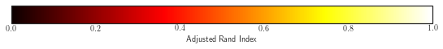

```
Original signal
```

[figure not shown]

```
1st derivative
```

[figure not shown]

```
2nd derivative
```

[figure not shown]

```python
sns.set_style('white')
cmapHot = plt.get_cmap('hot')

fig = plt.figure( figsize = ( 8 , 3 ))
ax1 = fig.add_axes([ 0.05 , 0.80 , 0.9 , 0.1 ])
norm = mpl.colors.Normalize(vmin=0., vmax=1.)

cb1 = mpl.colorbar.ColorbarBase(
    ax1, cmap=cmapHot, norm=norm, orientation = 'horizontal'
)
cb1.set_label('Adjusted Rand Index')
plt.show()

print "Original signal"
custom_mosaic_plain(mosaic_data_ari_plain, mosaic_data_3var_dict, cmapHot)
plt.show()
print "1st derivative"
custom_mosaic_plain(mosaic_data_ari_d1, mosaic_data_3var_dict, cmapHot)
plt.show()
print "2nd derivative"
custom_mosaic_plain(mosaic_data_ari_d2, mosaic_data_3var_dict, cmapHot)
plt.show()
```

Return to contents